# Regressão Linear com apoio do R

Prof. Alessandro de Castro Corrêa

06 abril, 2023

# 1 Apresentação

Este texto reúne um conjunto de notas de apoio do ensino de Regressão Linear na disciplina *Métodos Quantitativos Aplicados* ministrada nos cursos de graduação e das atividades do Grupos de Estudos Avançados em Gestão (GEAG) no Instituto Federal do Pará (IFPA).

# 2 Regressão

A regressão é utilizada para explicar e modelar a relação entre uma variável $y$, denominada resposta ou variável dependente e uma ou mais variáveis independentes, explicativas ou fatores, $x_1,\dots, x_k$ (Faraway 2002). Quando, no modelo, só há uma variável explicativa, $k=1$, chama-se **regressão simples**, mas quando há mais de uma variável explicativa, $k>1$, chama-se **regressão múltipla**.

$$y=f(x_1,x_2, \dots,x_k)$$

A variável dependente deve ser contínua, mas as variáveis independentes podem ser contínuas, discretas ou categóricas.

A regressão pode ser utilizadas para três finalidades básicas:

1. **Previsão**: estimar valores da variável dependente com base nos valores das variáveis independentes;
2. **Análise**:Analisar os efeitos de variações nas variáveis independentes ou fatores sobre a variável dependente ou resposta;
3. **Descrição**: descrever a estrutura geral de dados.

A regressão busca explicar porque os valores de cada uma das observações de $y$ são diferentes umas das outras com base na informação dos valores de $x$ associados. O valor esperado de cada $y$ para cada valor de $x$ pode ser descrito pelo seguinte modelo:

$$E(y|x)=\beta_0+\beta_1X$$

em que o intercepto $\beta_0$ e ao coeficiente de inclinação $\beta_i$ são constantes desconhecidas. Supondo a existência de uma única variável explicativa, os valores de $y_i$ podem ser descritas pelo modelo

$$y=\beta_0+\beta_1 X+
\epsilon$$

em que $\epsilon$ representa um termo aleatório com média zero e variância $\sigma^2$.

Na Figura abaixo, a reta de regressão cruza as observações dos pares ordenados $(x,y)$ com o melhor ajuste e $\beta_0$ e $\beta_1$ são, respectivamente os coeficientes lineares e de inclinação dessa reta.

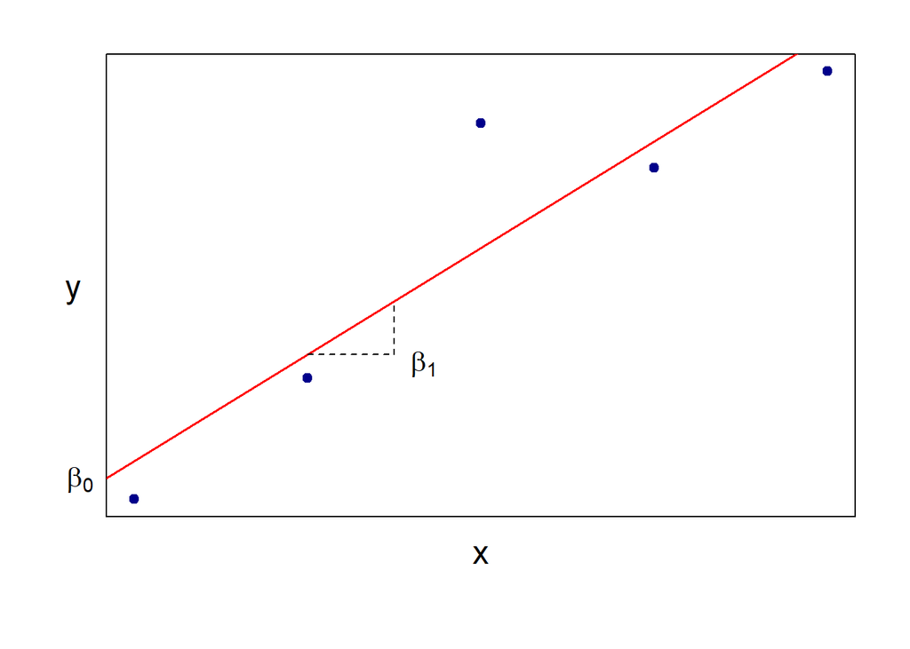

Na presença de mais de uma variável explicativa, o modelo descritivo de $y_i$ pode ser:

$$y_i = \beta_0 + \beta_1 x_ + \beta_2 x_2
+ \dots + \beta_k x_k+\varepsilon_i\:,\:\: i=1,\dots,N$$

em que **y** corresponde ao i-ésimo valor da observado da variável dependente, *i* é o número da observação, $x_k$ correspondem à variàveis independentes, $\varepsilon_i$ são os valores do termo aleatório, $\beta_0$ é uma constante que representa o coeficiente linear ou intercepto do modelo, $\beta_1,\dots,\beta_k$ são os parâmetros de declividade ou coeficiente angular e **N** é o total de observações.

Os valores de cada uma das observações de ($y_i$) podem ser descritos por **N** equações, como a seguir:

$$\begin{array}{{c@{}}@{}*{7}}
y_1 & {}={} & \beta_0 & {}+{} & \beta_1 x_{11} &
{}+{} & \beta_2 x_{12} & {}+ \cdots +{} & \beta_{k} x_{1k}
\\
y_2 & {}={} &\beta_0 & {}+{} & \beta_1 x_{21} &
{}+{} & \beta_2 x_{22} & {}+ \cdots +{} & \beta_k x_{2k}
\\[-2pt]
\vdots & & \vdots & &
\vdots & & \vdots & &
\vdots \\
y_N & {}={} &\beta_0 & {}+{} & \beta_1 x_{N1} &
{}+{} & \beta_2 x_{N2} & {}+ \cdots +{} & \beta_k x_{Nk}
\end{array}$$

O sistema de equações acima pode ser reescrito de forma mais concisa em notação matricial:

$$\mathbf{Y}=\mathbf{X}\boldsymbol{\beta}+\boldsymbol{\varepsilon}$$

Em que

$$\mathbf{\underset{N\times 1}y} =
\begin{bmatrix}
y_1\\ y_2\\ \vdots\\ y_N
\end{bmatrix}
\mathbf{\underset{N\times (k+1)}X} =
\begin{bmatrix} 1 & x_{11} & x_{12} & \dots & x_{1k} \\
1 & x_{21} & x_{22} & \dots & x_{1k} \\
\vdots & \vdots & \vdots & \ddots &
\vdots\\
1 & x_{N1} & x_{N2} & \dots & x_{Nk}
\end{bmatrix}$$

$$\mathbf{\underset{(k+1)\times 1}\beta} =
\begin{bmatrix}
\beta_0\\ \beta_1
\end{bmatrix}
\mathbf{\underset{N\times 1} \varepsilon} =
\begin{bmatrix}
\varepsilon_1\\ \varepsilon_2\\ \vdots\\ \varepsilon_N
\end{bmatrix}$$

O modelo proposto possui dois componentes: um **componente sistemático** ($\mathbf{X}\boldsymbol{\beta}$) e um **componente aleatório** ($\boldsymbol{\varepsilon}$) ou estocástico e, tendo em vista que geralmente se assume que o termo aleatório possui média zero, temos que

$$\mathbf{y}=\mathbf{X}\boldsymbol{\beta}$$

Como o valores de X e Y são conhecidos por meio de observação ou experimentação, resta a obtenção das estimativas dos parâmetros do vetor $\boldsymbol{\beta}$ que serão os elementos do vetor $\mathbf{b}$ a seguir:

$$\mathbf{y}=\mathbf{Xb}$$

No caso dos modelos lineares, o cálculo de $\mathbf{b}$ pode ser realizado pelo método dos Mínimos Quadrados Ordinários (MQQ) ou método de Máxima Verossimilhança (MVS).

# 3 Estimativa do modelo

Uma vez de posse da estimativa de $\boldsymbol{\beta}$, o modelo permite estimar os valores estimados da variável dependentes contidos no vetor $\mathbf{\hat{y}}$:

$$\mathbf{\hat{y}}=\mathbf{Xb}$$

O método dos MQO envolve encontrar $\mathbf{b}$ que minimize a soma dos quadrados dos resíduos. O resíduo ($e_i$) pode ser definido como a diferença entre o valor observado ($y_i$) é aquele calculado pelo modelo, denominado valor ajustado ou previsto ($\hat{y}$), podendo se expresso como abaixo e é ilustrado na Figura a seguir:

$$e_i =y_i-\hat{y}_i$$

Os resíduos são estimativas dos valores do termo aleratório $\epsilon$ os quais não são observáveis.

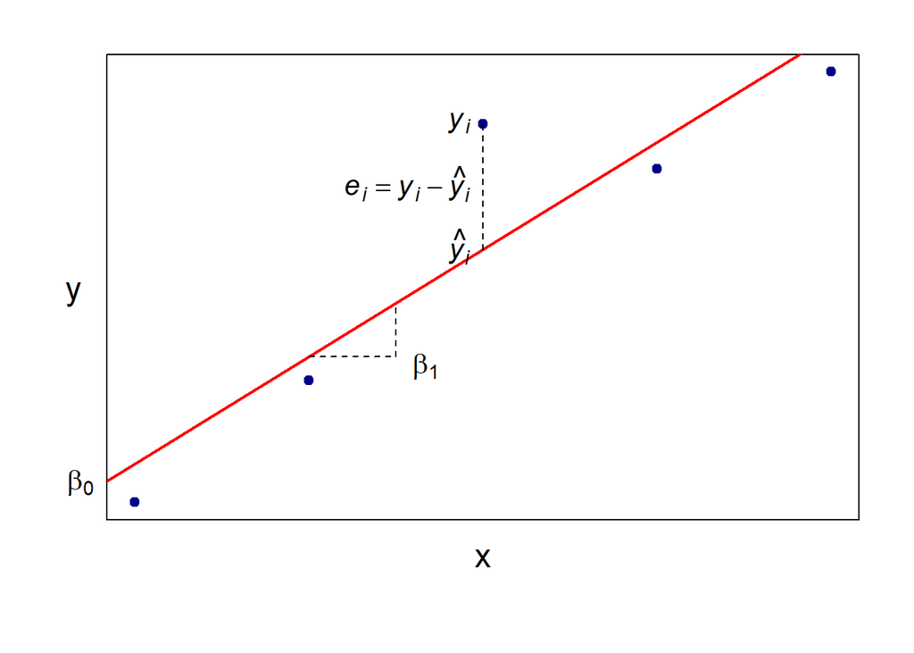

O vetor de resíduos é

$$\begin{align}
\mathbf{e} & =\mathbf{y-\hat{y}}\\
& =\mathbf{y-Xb}
\end{align}$$

A soma dos quadrados dos resíduos (SQR) é

$$\mathbf{e'e}=\begin{bmatrix}
e_1, e_2, \dots, e_N\\
\end{bmatrix}
\begin{bmatrix}
e_1\\ e_2\\ \vdots\\ e_N
\end{bmatrix}$$

Que pode ser reescrita e desenvoldida da seguinte forma:

$$\begin{align}
\mathbf{e'e} & =
\left(\mathbf{\hat{y}-y}\right)'\left(\mathbf{\hat{y}-y}\right)\\
& = \left(\mathbf{y-Xb}\right)'\left(\mathbf{y-Xb}\right) \\
& =
\mathbf{y'y}-\mathbf{b'X'y}-\mathbf{b'X'y}-\mathbf{b'X'y}+\mathbf{b'X'Xb}
\\
& = \mathbf{y'y}-2\mathbf{b'X'y}+\mathbf{b'X'Xb}
\end{align}$$

Deve-se ressaltar que, para o desenvolvimento acima, leva-se em consideração que a transposta de um escalar também é um escalar $\mathbf{y'Xb}=$ $\left(\mathbf{y'Xb}\right)'= \mathbf{b'X'y}$

$$\frac{d\left(\mathbf{e'e}\right)}{d\mathbf{b}}=
-2\mathbf{X'y}+2\mathbf{X'Xb}$$

Se
$$\frac{d\left(\mathbf{e'e}\right)}{d\mathbf{b}}=0$$

$$-2\mathbf{X'y}+2\mathbf{X'Xb}=0$$

logo

$$\left(\mathbf{X'X}\right)
\mathbf{b}=\mathbf{X'y}$$

Multiplicando ambos os lados por $\left(\mathbf{X'}\mathbf{X}\right)^{-1}$:

$$\left(\mathbf{X'X}\right)^{-1}\left(\mathbf{X'X}\right)
\mathbf{b}=\left(\mathbf{X'X}\right)^{-1}\mathbf{X'y}$$

Temos que

$$\mathbf{b}=(\mathbf{X'X})^{-1}\mathbf{X'y}$$

$\mathbf{b}$ é vetor cujos elementos são as estimativas dos mínimos quadrados dos elementos de $\mathbf{\beta}$.

# 4 Exemplo 1

Os dados do exemplo foram extraídos de Vasconcellos and Alves (2000) e estão em **consRenda.txt**.

Dados fictícios de consumo agregado e renda nacional.

| Consumo Agregado | Renda Nacional |
| --- | --- |
| 2.0 | 3 |
| 3.0 | 4 |
| 4.0 | 5 |
| 4.0 | 6 |
| 4.5 | 7 |
| 5.0 | 9 |
| 6.0 | 10 |
| 6.5 | 11 |
| 6.0 | 12 |
| 7.5 | 12 |
| 8.0 | 14 |

```r
consRenda <- read.table('consRenda.txt',head=T)
y <- as.matrix(consRenda$cons)
X <- as.matrix(consRenda$renda)

N <- nrow(y)
const<-matrix(rep(1,times = N))

X<-cbind(const,X)
X
```

```
##       [,1] [,2]
##  [1,]    1    3
##  [2,]    1    4
##  [3,]    1    5
##  [4,]    1    6
##  [5,]    1    7
##  [6,]    1    9
##  [7,]    1   10
##  [8,]    1   11
##  [9,]    1   12
## [10,]    1   12
## [11,]    1   14
```

```r
dim(X)
```

```
## [1] 11  2
```

```r
# b=(X'X)^-1*X'*y
b <- solve(t(X)%*% X) %*% t(X)%*%y # b
b
```

```
##           [,1]
## [1,] 0.9746964
## [2,] 0.4922402
```

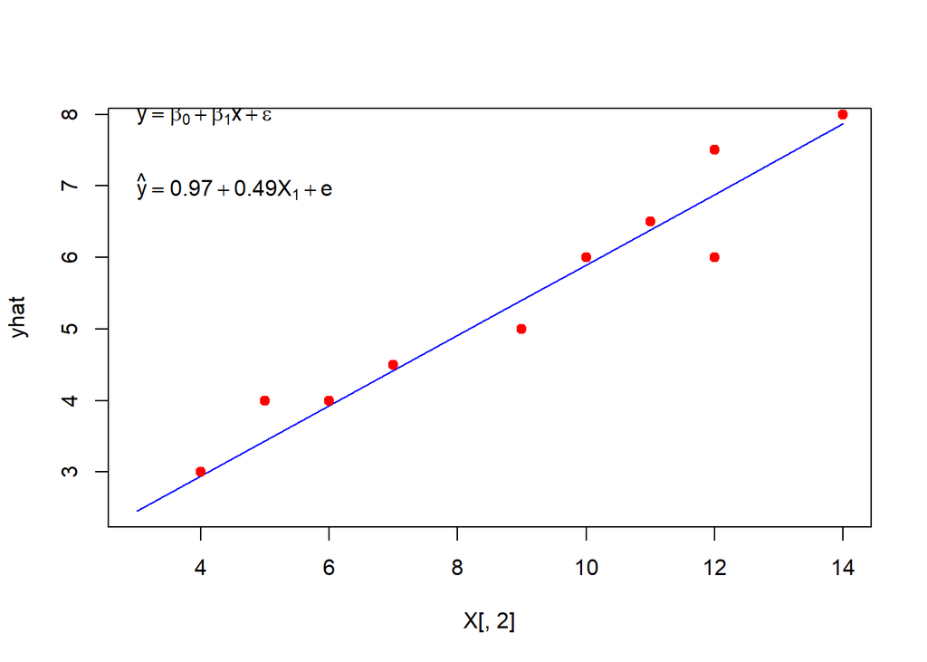

```r
yhat<- X%*%b # valores estimados de Y
plot(X[,2],yhat, type = "l", col = "blue")
points(X[,2],y, pch = 19, col = "red")

text(min(X[,2]), 8,
     expression(y==beta[0] + beta[1]*x + epsilon),
     adj = 0)

text(min(X[,2]), 7,
     expression(hat(y)==0.97 + 0.49*X[1] + e),
     adj = 0)
```

```r
# e = Y-Xb
y - X%*%b # Erros
```

```
##              [,1]
##  [1,] -0.45141700
##  [2,]  0.05634278
##  [3,]  0.56410256
##  [4,]  0.07186235
##  [5,]  0.07962213
##  [6,] -0.40485830
##  [7,]  0.10290148
##  [8,]  0.11066127
##  [9,] -0.88157895
## [10,]  0.61842105
## [11,]  0.13394062
```

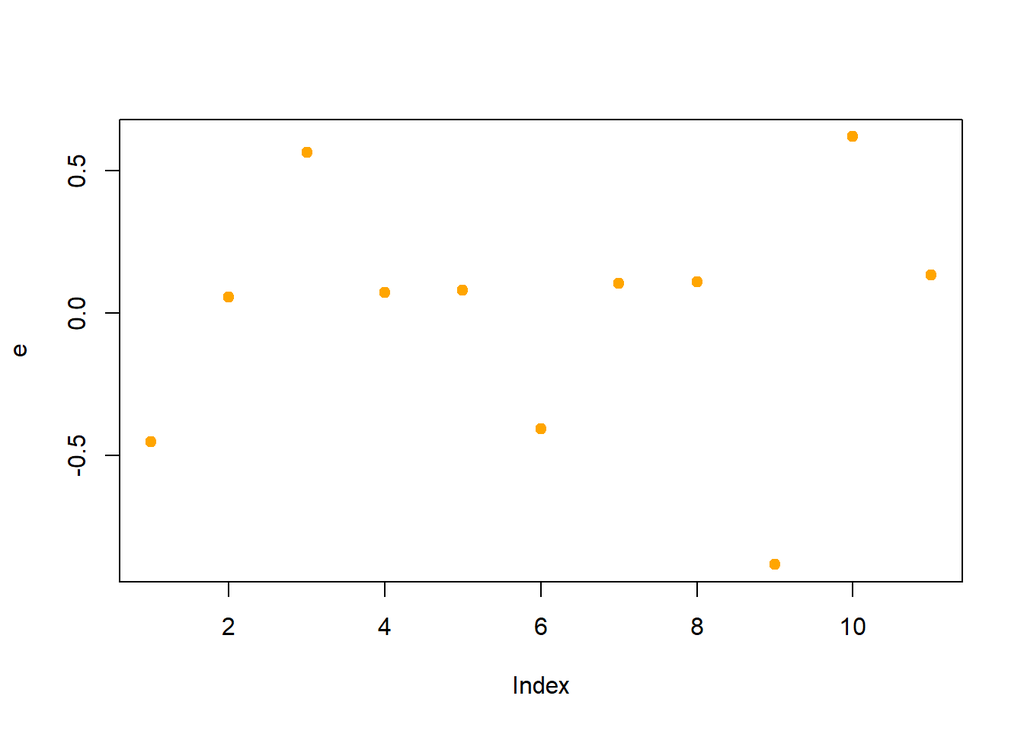

```r
e <- y - X%*%b # Erros
plot(e, pch=21, col="orange",bg="orange")
```

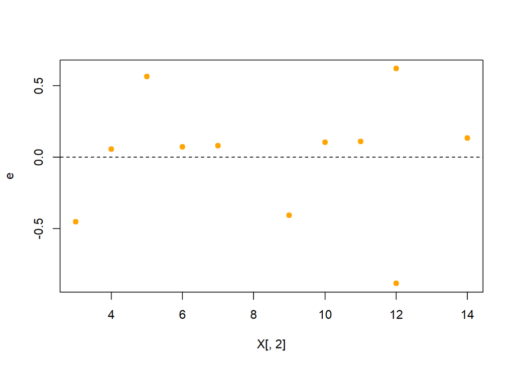

```r
plot(X[,2], e, pch=21, col="orange",bg="orange")
abline(h=0, lty = "dashed")
```

# 5 Exercício

Estimar um modelo de regressão simples que explique as despesas com alimentação com base na renda. Os dados extraídos de Griffiths, Hill, and Judge (2003) estão em **food.txt**.

# 6 Estimativa da variância

$$\mathbf{e'e} =
\left(\mathbf{\hat{y}-y}\right)'\left(\mathbf{\hat{y}-y}\right)$$

$$s^2 =
\frac{1}{N-(k+1)}\sum_{i=1}^{N}e^2$$

$$s^2 = \frac{1}{N-(k+1)}
\mathbf{e'e}$$

$$s^2 =
\frac{1}{N-(k+1)}\left(\mathbf{\hat{y}-y}\right)'\left(\mathbf{\hat{y}-y}\right)$$

$$s^2 = \frac{1}{N-(k+1)}SQR$$
onde SSQ é a Soma dos Quadrados dos Resíduos. O divisor é número de graus de liberdade de $s^2$. Quando o modelo verdadeiro é descrito por $y=X\beta+\varepsilon$, $s^2$ é o estimador não tendencioso de $\sigma^2$.

# 7 Estimativa da Variância de beta

A variância de beta é calculada por meio da Equação:

$$var(\mathbf{b}) =
\sigma^2(\mathbf{X'X})^{-1}$$

$$var(\mathbf{b}) =
s^2(\mathbf{X'X})^{-1}$$
Deve-se ressaltar que $var(\mathbf{b})$ é uma matriz de variância e covariância de ordem $p\times p$ do vetor $\mathbf{b}$ no qual os elementos da diagonal principal são os valores de $var(b_i)$ e os demais elementos correspondem a $cov(b_i,b_j)$

$$\begin{bmatrix} var(b_1) & cov(b_1,b_2) & \dots &
cov(b_1,b_k) \\
cov(b_2,b_1) & var(b_2) & \dots &
cov(b_2,b_k) \\
\vdots & \vdots & \ddots & \vdots\\
cov(b_k,b_1) & cov(b_k,b_2) & \dots &
var(b_k)
\end{bmatrix}$$

Se assumirmos que $\varepsilon\sim N(0, \sigma^2 I)$, então

$$\mathbf{b} \sim
(\mathbf{\beta},\sigma^2(\mathbf{X'X})^{-1})$$

e cada beta individual é

$$b_i \sim
(\beta_i,\sigma^2((\mathbf{X'X})^{-1})_{ii})$$
O erro padrão de cada $b_i$ é

$$ep(b_i)=\sqrt{var(b_i)}$$

# 8 Cálculo no R com álgebra matricial

```r
N <- p<-dim(X)[1] # no. obs.
p <- dim(X)[2]    # no. de parametros
s2 <- as.numeric(1/(N-p)*t(e)%*%e) # escalar

s2*solve(t(X)%*%X)
```

```
##             [,1]         [,2]
## [1,]  0.13126414 -0.013254685
## [2,] -0.01325469  0.001567758
```

```r
varb <- diag(s2*solve(t(X)%*%X))
varb
```

```
## [1] 0.131264141 0.001567758
```

```r
epb <- sqrt(varb)
epb
```

```
## [1] 0.36230393 0.03959493
```

# 9 Exemplo 2

Os dados do exemplo se referem à produção de um fábrica de chocolateforam extraídos de Fávero et al. e estão em **FabricaChocolates.RData**.

- **ci** são os custos industriais;
- **emb** é a quantidade de embalagens produzidas;
- **ton** é a quatidade em tonelada de chocolate produzido pela fábrica.

O propósito de um gestor é avaliar o impacto da produção da quantidade de embalagens e de toneladas de chocolote produzidos sobre os custos industriais.

```r
load("FabricaChocolates.RData")

# Inspecionar dados
str(FabricaChocolates)
```

```
## 'data.frame':    30 obs. of  10 variables:
##  $ data     : chr  "Jan2006" "Fev2006" "Mar2006" "Abr2006" ...
##  $ ci       : num  230001 221034 240423 185955 218055 ...
##  $ emb      : num  2658 2730 2451 1509 2075 ...
##  $ ton      : num  47 33 59 60 59 62 72 51 38 44 ...
##  $ ferias   : num  1 1 0 0 0 0 1 0 0 0 ...
##  $ ano2007  : num  0 0 0 0 0 0 0 0 0 0 ...
##  $ ano2008  : num  0 0 0 0 0 0 0 0 0 0 ...
##  $ intferias: num  47 33 0 0 0 0 72 0 0 0 ...
##  $ int2007  : num  0 0 0 0 0 0 0 0 0 0 ...
##  $ int2008  : num  0 0 0 0 0 0 0 0 0 0 ...
```

```r
head(FabricaChocolates)
```

```
##      data     ci  emb ton ferias ano2007 ano2008 intferias int2007 int2008
## 1 Jan2006 230001 2658  47      1       0       0        47       0       0
## 2 Fev2006 221034 2730  33      1       0       0        33       0       0
## 3 Mar2006 240423 2451  59      0       0       0         0       0       0
## 4 Abr2006 185955 1509  60      0       0       0         0       0       0
## 5 Mai2006 218055 2075  59      0       0       0         0       0       0
## 6 Jun2006 263025 2936  62      0       0       0         0       0       0
```

```r
y <- as.matrix(FabricaChocolates$ci)
X <-cbind(FabricaChocolates$emb,FabricaChocolates$ton)

N <- nrow(y)
const<-matrix(rep(1,times = N))

X<-cbind(const,X)
dim(X)
```

```
## [1] 30  3
```

```r
# b=(X'X)^-1*X'*y
b <- solve(t(X)%*% X) %*% t(X)%*%y # b
b
```

```
##             [,1]
## [1,] 34893.14132
## [2,]    57.34018
## [3,]   986.95192
```

# 10 Funções de regressão do R

```r
load("FabricaChocolates.RData")


mod <- lm(ci ~ emb + ton, data = FabricaChocolates)

summary(mod)
```

```
##
## Call:
## lm(formula = ci ~ emb + ton, data = FabricaChocolates)
##
## Residuals:
##      Min       1Q   Median       3Q      Max
## -15060.9  -3719.6    -66.1   5056.4  13320.2
##
## Coefficients:
##              Estimate Std. Error t value Pr(>|t|)
## (Intercept) 34893.141   7854.543   4.442 0.000136 ***
## emb            57.340      2.882  19.899  < 2e-16 ***
## ton           986.952     91.685  10.765 2.86e-11 ***
## ---
## Signif. codes:  0 '***' 0.001 '**' 0.01 '*' 0.05 '.' 0.1 ' ' 1
##
## Residual standard error: 6645 on 27 degrees of freedom
## Multiple R-squared:  0.9511, Adjusted R-squared:  0.9475
## F-statistic: 262.5 on 2 and 27 DF,  p-value: < 2.2e-16
```

# Referências

Faraway, Julian J. 2002. *Practical Regression and ANOVA Using r*. Bath, United Kingdom: University of Bath. http://csyue.nccu.edu.tw/Practical%20Regression%20and%20Anova%20using%20R.pdf.

Griffiths, William, Carter Hill, and George Judge. 2003. *Econometria*. São Paulo-SP: Editora Saraiva.

Vasconcellos, Marco Antonio Sandoval, and Denisard Alves. 2000. *Manual de Econometria*. São Paulo-SP: Atlas.